# Reproducible Research

## I used the mean number of steps perinterval to fill missing values

## Finding the mean number of steps per interval

```r
m <- mean(averageStepsbyInterval$steps)
```

## 3. One can create a new dataset that is equal to the original dataset but wiht the missing data filled in

Imputing missing values with M=37.3825996

```r
activity1 <- activity
activity1[missingIndex, 1] <- m
```

## Make a histogram of the total number of steps taken each day and calculate and report the mean an d median number of steps taken per day. are they different, what is the impact

## Finding the total number of steps each day after missing values are imputed and making histogram

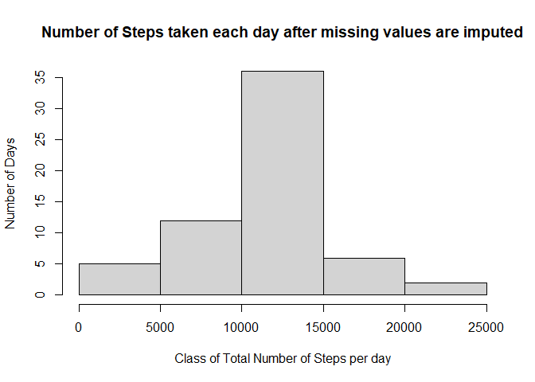

```r
   totalStepsByDay1 <- aggregate(steps~date, activity1, sum)
   hist(totalStepsByDay1$steps, xlab = "Class of Total Number of Steps per day", ylab = "Number of Days", main = "Number of Steps taken each day after missing values are imputed")
```

## To calculate the mean and median total number of steps per day, first find the total number of steps per day.

```r
totalStepsByDay1 <- aggregate(steps~date, activity1, sum)
```

```r
mean_afterImput <- mean(totalStepsByDay1$steps)
mean_afterImput
```

```
## [1] 10766.19
```

```r
median_afterImput <- median(totalStepsByDay1$steps)
median_afterImput
```

```
## [1] 10766.19
```

## By imputting the missing values by the mean number of steps per interval, there is no differnce in mean before and after imputing that is surprising. The median has changed a little bit.

## ** Are there differnces in activity patterns between weekdays and weekends?** ## Using the weekdays() and the dataset with the filled missing values. ## 1. Create a new factor variable in the dataset with two levels - ’Weekdays" and “Weekends” indicating whether a given date is a weekend or weekday.

```r
 activity1$date <- as.Date(activity1$date)
 library(dplyr)
 activity2 <- activity1%>%
  mutate(dayType= ifelse(weekdays(activity1$date) == "Saturday" | weekdays(activity1$date) == "Sunday", "Weekend", "Weekday"))
head(activity2)
```

```
##     steps       date interval dayType
## 1 37.3826 2012-10-01        0 Weekday
## 2 37.3826 2012-10-01        5 Weekday
## 3 37.3826 2012-10-01       10 Weekday
## 4 37.3826 2012-10-01       15 Weekday
## 5 37.3826 2012-10-01       20 Weekday
## 6 37.3826 2012-10-01       25 Weekday
```

```r
 averageStepByDayTypeAndInterval <- activity2 %>% group_by(dayType, interval) %>%
 summarize(averageStepByDay=sum(steps))
 head(averageStepByDayTypeAndInterval)
```

```
## # A tibble: 6 x 3
## # Groups:   dayType [1]
##   dayType interval averageStepByDay
##   <chr>      <int>            <dbl>
## 1 Weekday        0             315.
## 2 Weekday        5             242.
## 3 Weekday       10             231.
## 4 Weekday       15             232.
## 5 Weekday       20             228.
## 6 Weekday       25             283.
```

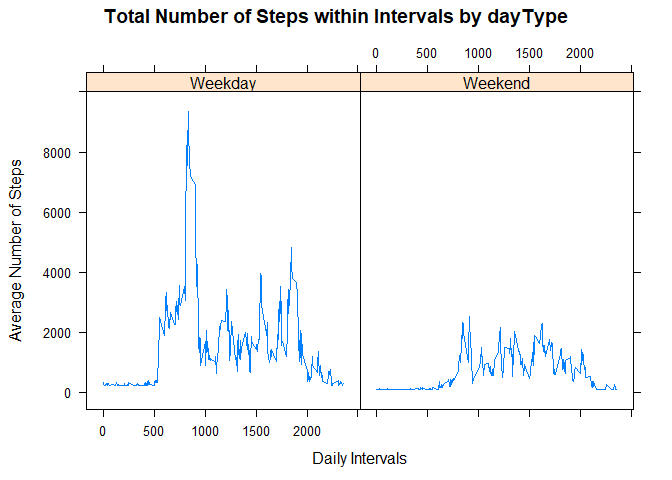

```r
 library(lattice)
 with(averageStepByDayTypeAndInterval, xyplot(averageStepByDay ~ interval | dayType, type = "l",
 main = "Total Number of Steps within Intervals by dayType", xlab = "Daily Intervals", ylab = "Average Number of Steps"))
```